# TMA4268 Statistical Learning V2019

Module 8: TREE-BASED METHODS

Thea Roksvaag, Mette Langaas, Department of Mathematical Sciences, NTNU

03.03.2019

# Solutions to Recommended Exercises

## 1. Theoretical

See Module 5 Recommended exercise solution for the bootstrap result.

## 2. Understanding

See solutions to exercise Q1 and Q4 here: https://rstudio-pubs-static.s3.amazonaws.com/65564_925dfde884e14ef9b5735eddd16c263e.html

See solutions to 2c-f: https://www.math.ntnu.no/emner/TMA4268/2019v/8Trees/TMA4268M8RecEx2ctof.pdf

## 3. Implementation:

### a)

We have 4601 observations and 58 variables, 57 of them will be used as covariates.

```r
library(kernlab)
`?`(spam)
```

### b)

We use approximately $2/3$ of the observations as the train set and $1/3$ as the test set.

```r
library(tree)

set.seed(1)

data(spam)
N = dim(spam)[1]

train = sample(1:N, 3000)
test = (1:N)[-train]
```

### c)

We fit a classification tree to the training data.

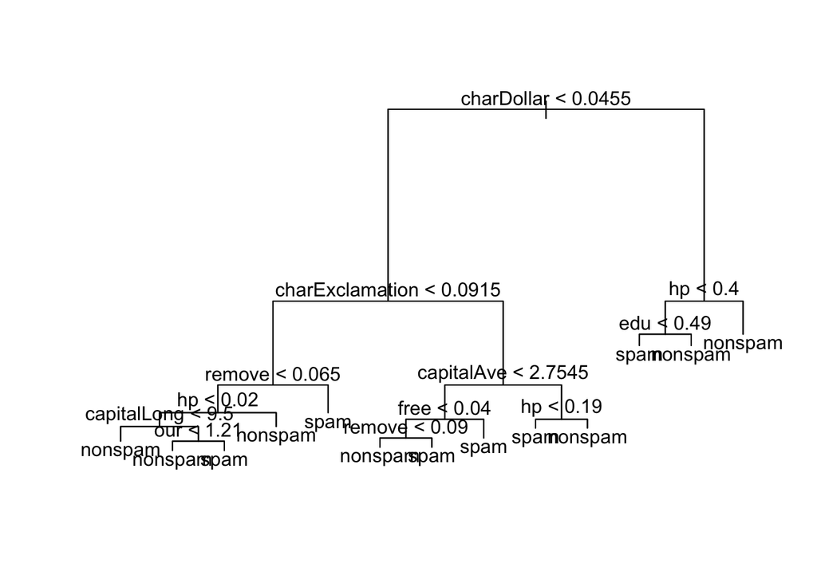

```r
tree.spam = tree(type ~ ., spam, subset = train)

plot(tree.spam)

text(tree.spam, pretty = 1)
```

```r
summary(tree.spam)
```

```
##
## Classification tree:
## tree(formula = type ~ ., data = spam, subset = train)
## Variables actually used in tree construction:
## [1] "charDollar"      "charExclamation" "remove"          "hp"
## [5] "capitalLong"     "our"             "capitalAve"      "free"
## [9] "edu"
## Number of terminal nodes:  13
## Residual mean deviance:  0.4983 = 1488 / 2987
## Misclassification error rate: 0.08033 = 241 / 3000
```

### d)

We predict the response for the test data.

```r
yhat = predict(tree.spam, spam[test, ], type = "class")
response.test = spam$type[test]
```

and make a confusion table:

```r
misclass = table(yhat, response.test)
print(misclass)
```

```
##          response.test
## yhat      nonspam spam
##   nonspam     904   75
##   spam         72  550
```

The misclassification rate is given by:

```r
1 - sum(diag(misclass))/sum(misclass)
```

```
## [1] 0.09181761
```

### e)

We use *cv.tree()* to find the optimal tree size.

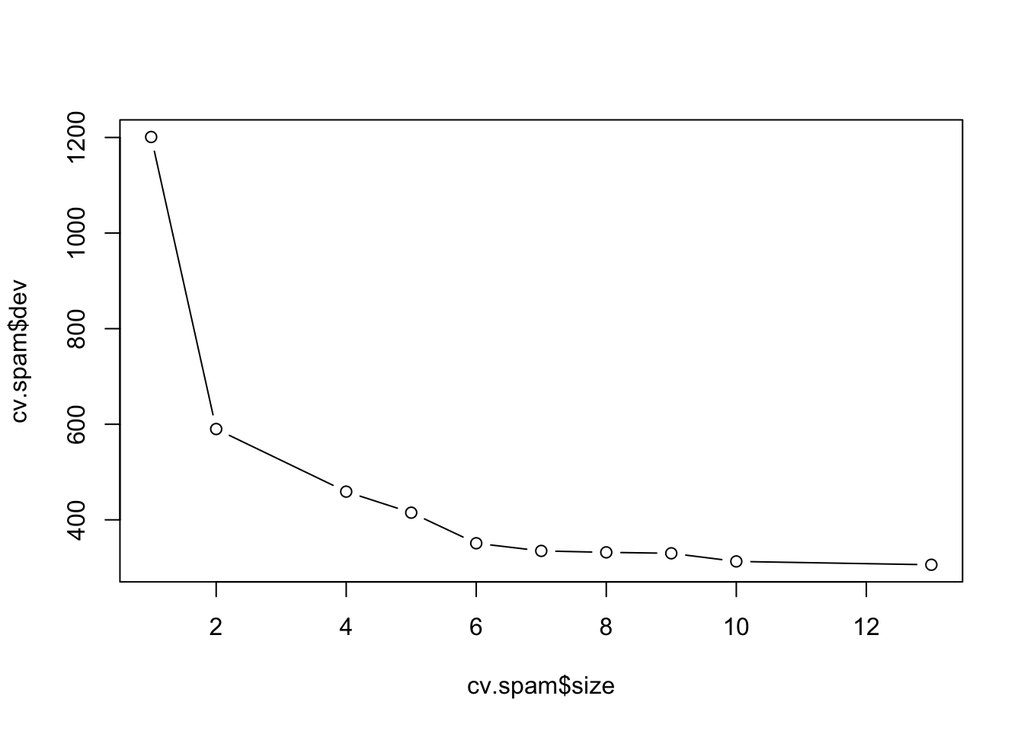

```r
set.seed(1)

cv.spam = cv.tree(tree.spam, FUN = prune.misclass)

plot(cv.spam$size, cv.spam$dev, type = "b")
```

According to the plot the optimal number of terminal nodes is 7 (or larger). We choose 7 as this gives the simplest tree, and prune the tree according to this value.

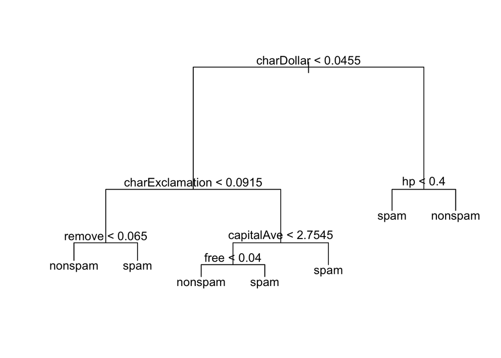

```r
prune.spam = prune.misclass(tree.spam, best = 7)

plot(prune.spam)
text(prune.spam, pretty = 1)
```

We predict the response for the test data:

```r
yhat.prune = predict(prune.spam, spam[test, ], type = "class")

misclass.prune = table(yhat.prune, response.test)
print(misclass.prune)
```

```
##           response.test
## yhat.prune nonspam spam
##    nonspam     892   94
##    spam         84  531
```

The misclassification rate is

```r
1 - sum(diag(misclass.prune))/sum(misclass.prune)
```

```
## [1] 0.1111805
```

### f)

We create a decision tree by bagging.

```r
library(randomForest)
bag.spam = randomForest(type ~ ., data = spam, subset = train, mtry = dim(spam)[2] -
    1, ntree = 500, importance = TRUE)
```

We predict the response for the test data as before:

```r
yhat.bag = predict(bag.spam, newdata = spam[test, ])

misclass.bag = table(yhat.bag, response.test)
print(misclass.bag)
```

```
##          response.test
## yhat.bag  nonspam spam
##   nonspam     932   49
##   spam         44  576
```

The misclassification rate is

```r
1 - sum(diag(misclass.bag))/sum(misclass.bag)
```

```
## [1] 0.05808869
```

### g)

We now use the random forest-algorithm and consider only $\sqrt{57}\approx 8$ of the predictors at each split. This is specified in *mtry*.

```r
set.seed(1)

rf.spam = randomForest(type ~ ., data = spam, subset = train, mtry = round(sqrt(dim(spam)[2] -
    1)), ntree = 500, importance = TRUE)
```

We study the importance of each variable

```r
importance(rf.spam)
```

```
##                      nonspam      spam MeanDecreaseAccuracy
## make               3.7106926  6.420583             6.875656
## address            6.9560490  6.007242             8.491042
## all                5.4977666 12.325039            12.232882
## num3d              5.4895675  4.538283             6.569200
## our               19.0702594 20.728272            24.117637
## over              12.1413796  9.795084            14.258429
## remove            35.0075329 29.197688            37.905961
## internet          17.4097498 10.702028            18.181981
## order              9.5480959  5.650150            10.472488
## mail               8.9561248  9.207912            11.760278
## receive           12.3069450  5.844350            13.394928
## will               7.7310375 16.248204            17.546926
## people             3.1117965  6.800867             6.922568
## report             5.7533164  6.769473             7.833354
## addresses          6.6664005  4.573558             7.733526
## free              31.6622555 27.112404            35.791600
## business          19.0766919 11.764762            20.243486
## email             10.3535985  7.826456            12.028503
## you               14.0188662 18.642762            21.698724
## credit            12.2629571  4.306761            12.725296
## your              19.9909130 25.601900            29.211840
## font               8.7669734  4.720813             9.363262
## num000            18.0528648 12.205178            19.363161
## money             15.2171668 14.735097            17.635124
## hp                24.5580004 34.288678            36.872253
## hpl               14.8464704 21.665639            24.122479
## george            14.0824656 23.516176            25.324531
## num650            11.8830753 14.350035            18.109587
## lab                0.6018690  8.988654             9.391188
## labs               6.0469190 10.178154            11.735195
## telnet             4.4734144  7.112928             7.479557
## num857             0.6437629  5.593084             5.692570
## data               2.2307640  7.009368             7.212093
## num415             2.9177565  5.627777             5.886071
## num85              5.2151469 10.287728            10.095952
## technology         8.6331089  7.479078            11.168371
## num1999           15.7322669 22.746573            24.837069
## parts             -0.4804300  5.911246             4.371374
## pm                 3.7499730 12.265635            11.606110
```

[output cut: 61 more lines]

```
## original                 2.2716718
## project                  2.2491866
## re                      11.8499184
## edu                     21.7211105
## table                    0.4296191
## conference               1.5614413
## charSemicolon            7.1880288
## charRoundbracket        15.8344882
## charSquarebracket        3.3167999
## charExclamation        180.0080435
## charDollar             149.2319049
## charHash                 4.4687720
## capitalAve              91.2654492
## capitalLong             77.3266819
## capitalTotal            60.1267373
```

If *MeanDecreaseAccuracy* and *MeanDecreaseGini* are large, the corresponding covariate is important.

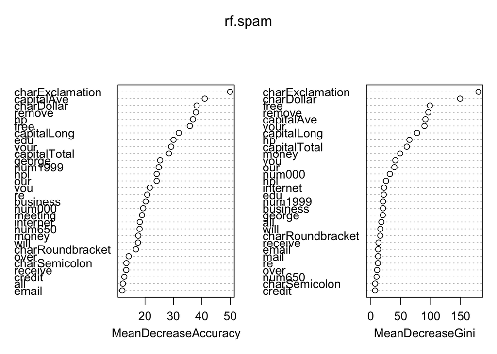

```r
varImpPlot(rf.spam)
```

We now predict the response for the test data.

```r
yhat.rf = predict(rf.spam, newdata = spam[test, ])

misclass.rf = table(yhat.rf, response.test)
1 - sum(diag(misclass.rf))/sum(misclass.rf)
```

```
## [1] 0.05121799
```

```r
print(misclass.rf)
```

```
##          response.test
## yhat.rf   nonspam spam
##   nonspam     943   49
##   spam         33  576
```

### h)

Finally, we create a tree by using the boosting algorithm. The *gbm()* function does not allow factors in the response, so we have to use “1” and “0” instead of “spam” and “nonspam”:

```r
library(gbm)
set.seed(1)

spamboost = spam
spamboost$type = c()
spamboost$type[spam$type == "spam"] = 1
spamboost$type[spam$type == "nonspam"] = 0

boost.spam = gbm(type ~ ., data = spamboost[train, ], distribution = "bernoulli",
    n.trees = 5000, interaction.depth = 4, shrinkage = 0.001)
```

We predict the response for the test data:

```r
yhat.boost = predict(boost.spam, newdata = spamboost[-train, ], n.trees = 5000,
    distribution = "bernoulli", type = "response")

yhat.boost = ifelse(yhat.boost > 0.5, 1, 0)  #Transform to 0 and 1 (nonspam and spam).

misclass.boost = table(yhat.boost, spamboost$type[test])

print(misclass.boost)
```

```
##
## yhat.boost   0   1
##          0 941  58
##          1  35 567
```

The misclassification rate is

```r
1 - sum(diag(misclass.boost))/sum(misclass.boost)
```

```
## [1] 0.05808869
```

### i)

We get lower misclassification rates for bagging, boosting and random forest as expected.

# Solutions to Compulsory Exercises 3, 2018

Problem 1 - Classification with trees: https://www.math.ntnu.no/emner/TMA4268/2018v/CompEx/Compulsory3solutions.html

# Solutions to Exam question 2018 Problem 4

Classification of diabetes cases c), with Q20, Q21, Q22.

https://www.math.ntnu.no/emner/TMA4268/Exam/e2018sol.pdf